# FPCC2 - Lab1 - Checkpoint4

## Dados

Os dados que são a base da análise descrevem os gastos realizados pelos deputados brasileiros no ano de 2016. Estes dados são abertos e disponibilizados pela própria câmara legislativa e podem ser encontrados neste link: [Site da câmara](http://www2.camara.leg.br/transparencia/cota-para-exercicio-da-atividade-parlamentar/dados-abertos-cota-parlamentar). Já para saber o que podemos encontrar nos dados, acessar [esse link](http://www2.camara.leg.br/transparencia/cota-para-exercicio-da-atividade-parlamentar/explicacoes-sobre-o-formato-dos-arquivos-xml).

```r
gastos_gerais = read_csv(file = "../data/gastos-cota_atividade_parlamentar.csv")
```

Além disso, iremos focar os estudos nos gastos realizados unicamente pelos parlamentares da Paraíba.

```r
gastos_pb = gastos_gerais %>%
  select(sgPartido, numAno, numMes, vlrGlosa, txNomeParlamentar, vlrDocumento, txtDescricao, txtFornecedor, vlrLiquido, txtPassageiro, txtTrecho, sgUF, nuDeputadoId, numSubCota) %>%
  filter(sgUF == "PB")
```

Antes de tudo vamos dar uma olhada em quem são e quantos deputados temos no estado e quais as categorias de gastos declaradas.

```r
parlamentares_pb = gastos_pb %>%
  select(txNomeParlamentar, sgPartido, nuDeputadoId) %>%
  distinct(txNomeParlamentar, sgPartido, nuDeputadoId)
  colnames(parlamentares_pb) = c("Nome_do_Parlamentar", "Partido", "Id")
  print(parlamentares_pb %>% select(Nome_do_Parlamentar, Partido ))
```

```
## # A tibble: 17 x 2
##        Nome_do_Parlamentar Partido
##                      <chr>   <chr>
## 1        AGUINALDO RIBEIRO      PP
## 2        BENJAMIN MARANHÃO      SD
## 3         DAMIÃO FELICIANO     PDT
## 4             EFRAIM FILHO     DEM
## 5               HUGO MOTTA    PMDB
## 6               LUIZ COUTO      PT
## 7            MANOEL JUNIOR    PMDB
## 8        MARCONDES GADELHA     PSC
## 9         PEDRO CUNHA LIMA    PSDB
## 10          RÔMULO GOUVEIA     PSD
## 11 VENEZIANO VITAL DO RÊGO    PMDB
## 12      WELLINGTON ROBERTO      PR
## 13            WILSON FILHO     PTB
## 14             MAJOR FÁBIO    PROS
## 15            NILDA GONDIM    PMDB
## 16            RUY CARNEIRO    PSDB
## 17            ANDRÉ AMARAL    PMDB
```

```r
tipoDeGastos = gastos_pb%>%
  select(txtDescricao, numSubCota)%>%
  unique()
  colnames(tipoDeGastos) = c("Despesa", "ID")
  print(tipoDeGastos %>% select(ID, Despesa))
```

```
## # A tibble: 15 x 2
##       ID                                                   Despesa
##    <int>                                                     <chr>
## 1      1 MANUTENÇÃO DE ESCRITÓRIO DE APOIO À ATIVIDADE PARLAMENTAR
## 2      3                             COMBUSTÍVEIS E LUBRIFICANTES.
## 3      5                      DIVULGAÇÃO DA ATIVIDADE PARLAMENTAR.
## 4      9                                          PASSAGENS AÉREAS
## 5     10                                                 TELEFONIA
## 6     11                                          SERVIÇOS POSTAIS
## 7     12                                 ASSINATURA DE PUBLICAÇÕES
## 8    120             LOCAÇÃO OU FRETAMENTO DE VEÍCULOS AUTOMOTORES
## 9    999                                     Emissão Bilhete Aéreo
## 10     4             CONSULTORIAS, PESQUISAS E TRABALHOS TÉCNICOS.
## 11    13                FORNECIMENTO DE ALIMENTAÇÃO DO PARLAMENTAR
## 12    14    HOSPEDAGEM ,EXCETO DO PARLAMENTAR NO DISTRITO FEDERAL.
## 13   122                 SERVIÇO DE TÁXI, PEDÁGIO E ESTACIONAMENTO
## 14     8  SERVIÇO DE SEGURANÇA PRESTADO POR EMPRESA ESPECIALIZADA.
## 15   119                        LOCAÇÃO OU FRETAMENTO DE AERONAVES
```

Como visto na tabela acima, existe uma categoria denomidada **Emissão Bilhete Aéreo** e outra denominada **PASSAGENS AÉREAS** o que provavelmente indica ser uma só categoria que foi dividida em duas por alguma razão. Para facilitar o entendimento e análise vamos juntar essas duas categorias e tratá-las como **PASSAGENS AÉREAS**.

```r
gastos_pb$txtDescricao[gastos_pb$txtDescricao == "Emissão Bilhete Aéreo"] <- "PASSAGENS AÉREAS"
gastos_pb$numSubCota[gastos_pb$numSubCota == 9] <- 999
```

```r
pb_2016 = gastos_pb %>%
  filter(numAno == 2016)

pb_2016_agrupado =  pb_2016%>%
  group_by(numMes, txtDescricao) %>%
  summarise(total_gasto = sum(vlrLiquido))
```

Passeando pelos dados foi possível observar que existem valores negativos como **Valor Líquido** da despesa. Investigando um pouco mais ficou claro que esses valores são estornos de companhias aéreas. Portanto, os valores negativos se anulam com valores positivos, representando, respectivamente, estornos de pagamentos feitos anteriormente. Podemos observar esses valores *estranhos* no sumário indicado abaixo.

```r
summary(pb_2016$vlrLiquido)
```

```
##    Min. 1st Qu.  Median    Mean 3rd Qu.    Max.
## -2820.0    73.2   200.0   844.4   680.5 73420.0
```

O gráfico abaixo identifica quais categorias concentram os maiores gastos dos nossos *amigos parlamentares*.

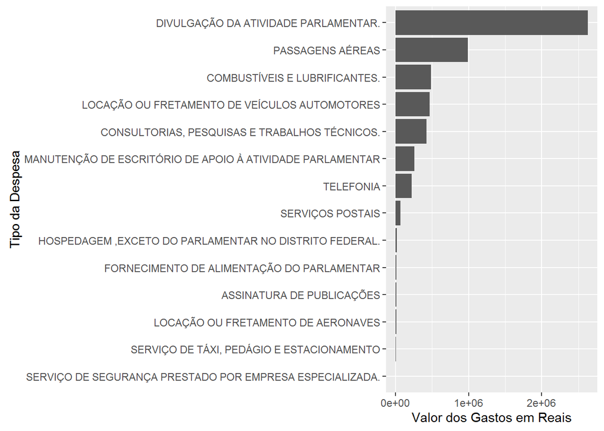

```r
pb_por_tipo = pb_2016 %>%
  select(txtDescricao, vlrLiquido) %>%
  group_by(txtDescricao)%>%
  summarise(total_gasto = sum(vlrLiquido))

ggplot(pb_por_tipo, aes(x=reorder(txtDescricao, total_gasto), y=total_gasto)) +
  geom_bar(stat = "identity") +
  coord_flip() +
  labs(x='Tipo da Despesa', y='Valor dos Gastos em Reais')
```

Já o próximo gráfico nos indica quais categorias de gastos que apresentam maior variação de valores

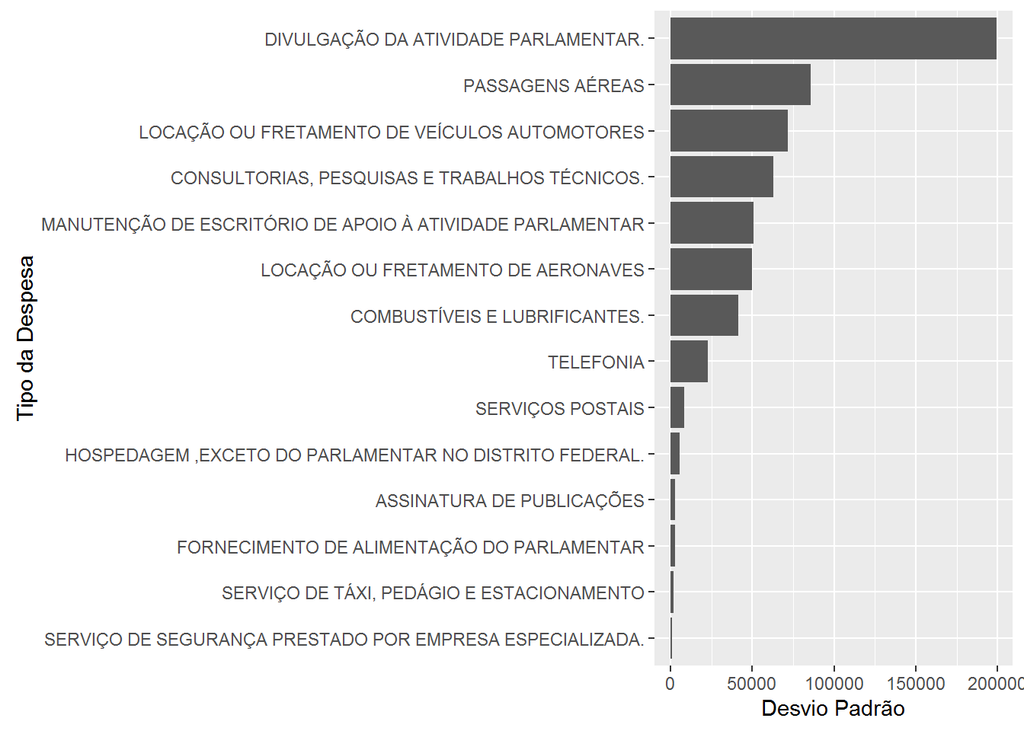

```r
pb_agrupado_parl_tipo = gastos_pb %>%
  select(txNomeParlamentar, txtDescricao, vlrLiquido) %>%
  group_by(txNomeParlamentar, txtDescricao) %>%
  summarise(total_gasto = sum(vlrLiquido))

pb_dp = pb_agrupado_parl_tipo %>%
  group_by(txtDescricao) %>%
  summarise(desvio_padrao = sd(total_gasto))

ggplot(pb_dp, aes(x=reorder(txtDescricao, desvio_padrao), y=desvio_padrao)) +
  geom_bar(stat = "identity") +
  labs(x='Tipo da Despesa', y='Desvio Padrão')+
  coord_flip()
```

Percebemos que **Divulgação da Atividade Parlamentar** está no topo dos dois gráficos, sendo onde mais se gasta dinheiro e também onde existe a maior variação dos valores gastos.

Tentando ver a distribuiçao de outra forma, é possível dizer que 75% dos gastos em **Divulgação da Atividade Parlamentar** não variam tanto, mas os outros 25% *que mais gastam* possui valores bem diferentes dos demais.

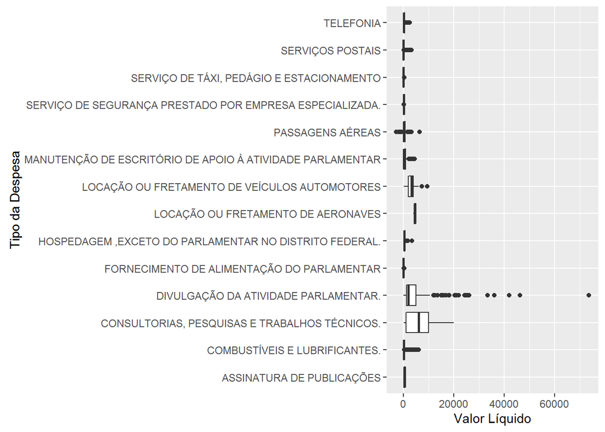

```r
ggplot(data = pb_2016, aes(x= txtDescricao, y=vlrLiquido)) +
  geom_boxplot() +
  labs(x='Tipo da Despesa', y='Valor Líquido') +
  coord_flip()
```

Expandindo a categoria **Divulgação da Atividade Parlamentar** vemos que *Manoel Júnior* foi quem mais gastou (R$ 73420,00 em 11/2016) seguido por *Benjamin Maranhão* com um gasto de R$ 46150,00 em 12/2016.

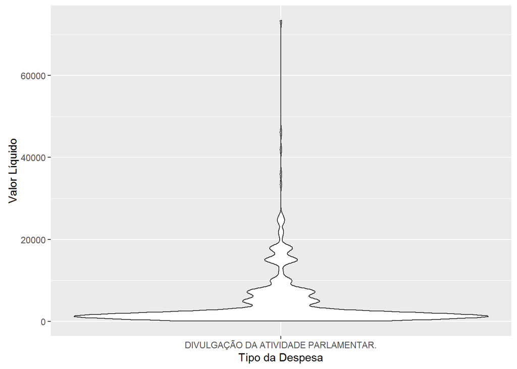

```r
divulgacao_2016 = pb_2016 %>%
  filter(txtDescricao == "DIVULGAÇÃO DA ATIVIDADE PARLAMENTAR.")

ggplot(divulgacao_2016, aes(x= txtDescricao, y=vlrLiquido)) +
  geom_violin() +
  labs(x='Tipo da Despesa', y='Valor Líquido')
```

```r
divulgacao_ordenada = divulgacao_2016[order(-divulgacao_2016$vlrLiquido), ]

head(divulgacao_ordenada)
```

```
## # A tibble: 6 x 14
##   sgPartido numAno numMes vlrGlosa  txNomeParlamentar vlrDocumento
##       <chr>  <int>  <int>    <dbl>              <chr>        <dbl>
## 1      PMDB   2016     11        0      MANOEL JUNIOR        73420
## 2        SD   2016     12        0  BENJAMIN MARANHÃO        46150
## 3        SD   2016      5        0  BENJAMIN MARANHÃO        41890
## 4        PR   2016     12        0 WELLINGTON ROBERTO        36000
## 5       DEM   2016      8        0       EFRAIM FILHO        33450
## 6       PTB   2016     12        0       WILSON FILHO        26092
## # ... with 8 more variables: txtDescricao <chr>, txtFornecedor <chr>,
## #   vlrLiquido <dbl>, txtPassageiro <chr>, txtTrecho <chr>, sgUF <chr>,
## #   nuDeputadoId <int>, numSubCota <dbl>
```

### Relacao entre ‘passagens aereas’ e ‘locacao ou fretamento de aeronaves’

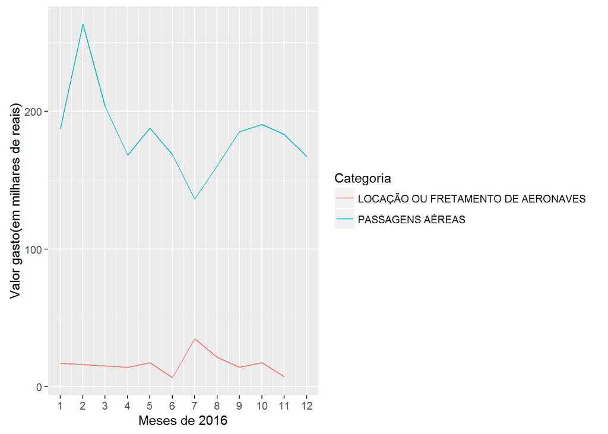

```r
categorias_aereo = c("LOCAÇÃO OU FRETAMENTO DE AERONAVES", "PASSAGENS AÉREAS")
gastos_com_aereo = gastos_pb %>%
  filter(txtDescricao %in% categorias_aereo) %>%
  group_by(numMes, txtDescricao) %>%
  summarise(total_gasto = sum(vlrLiquido))
meses = c("1","2","3","4","5","6","7","8","9","10","11","12")
ggplot(gastos_com_aereo, aes(x=numMes, y=total_gasto/1000, colour=txtDescricao))+
  geom_line( ) +
  scale_x_continuous(breaks = seq(1, 12, 1)) +
  labs(x="Meses de 2016", y="Valor gasto(em milhares de reais)", colour="Categoria")
```

Com o gráfico acima não podemos afirmar muita coisa. Apenas notamos uma particularidade: no mês de Julho(07), enquando o gasto com Passagens Aéreas **diminui**, o gasto com Locação ou Fretamento de Aeronaves **aumenta** e logo depois essa relação se inverte um pouco. Vamos ver se ao usar um gráfico diferente conseguimos ter dados que apoiem melhor a relação entre essas duas categorias.

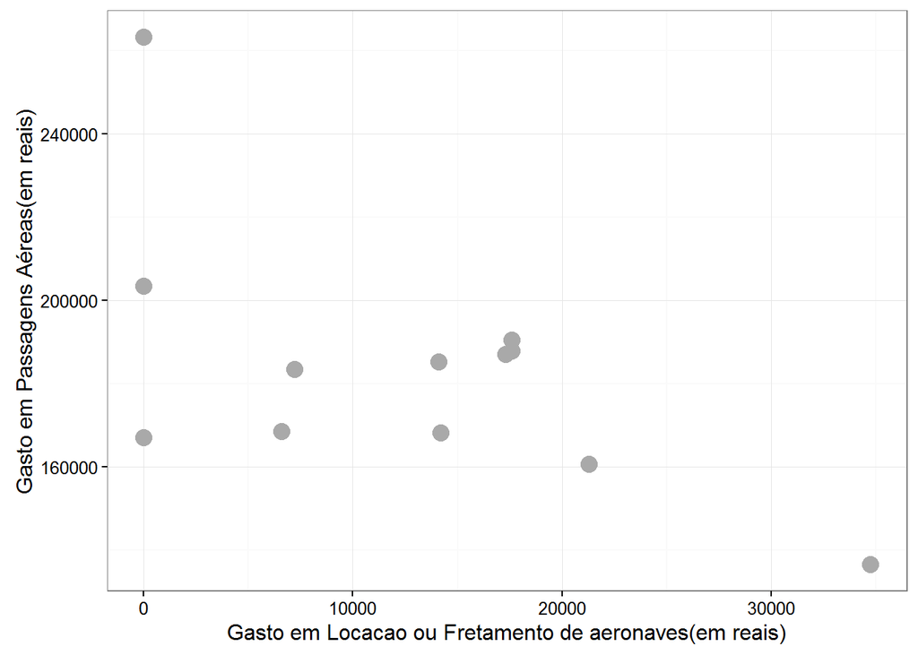

```r
aereo_wide = spread(gastos_com_aereo, txtDescricao, total_gasto)
aereo_wide[is.na(aereo_wide)] = 0
names(aereo_wide)[names(aereo_wide)=="LOCAÇÃO OU FRETAMENTO DE AERONAVES"] <- "locacao_ou_fretamento_de_aeronaves"
names(aereo_wide)[names(aereo_wide)=="PASSAGENS AÉREAS"] <- "passagens_aereas"

ggplot(aereo_wide, aes(x = locacao_ou_fretamento_de_aeronaves, y = passagens_aereas)) +
  geom_point(colour = "darkgrey", size = 4) +
  theme_bw() +
  labs(x="Gasto em Locacao ou Fretamento de aeronaves(em reais)", y="Gasto em Passagens Aéreas(em reais)")
```

Agora arriscamos dizer que o gráfico está decrescendo. Mas vamos buscar outra forma mais uma vez.

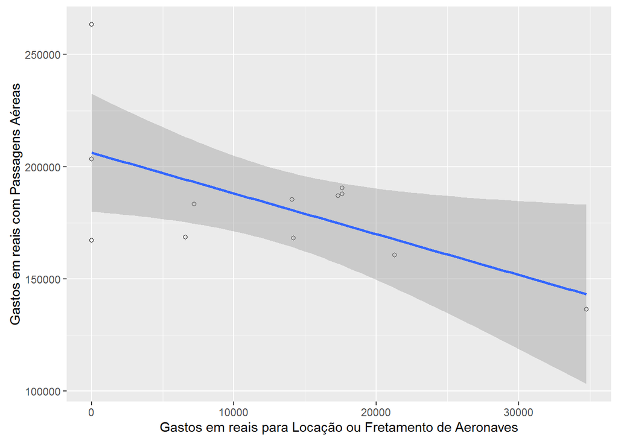

```r
ggplot(aereo_wide, aes(x=locacao_ou_fretamento_de_aeronaves, y=passagens_aereas)) +
  geom_point(shape=1) +    # Use hollow circles
  geom_smooth(method=lm) +
  labs(x="Gastos em reais para Locação ou Fretamento de Aeronaves", y="Gastos em reais com Passagens Aéreas")
```

Com o Scatter Plot fica mais claro o comportamento dos gastos. Como assim? Podemos observar que a medida que os pontos vão mais para a direita do gráfico *(aumento do valor gasto em Locação ou Fretamento de Aeronaves)*, eles simultaneamente também descem para mais próximo do eixo x, indicando dessa vez uma *diminuição nos gastos com Passagens Aéreas*. Dessa forma, podemos dizer que existe uma correlação negativa entre essas categorias, ou seja, quando uma aumenta, a outra decresce. Para nos dar mais segurança, vamos calcular o índice de correlação entre essas variáveis abaixo.

```r
locacao_aereo = gastos_com_aereo %>%
  filter(txtDescricao == "LOCAÇÃO OU FRETAMENTO DE AERONAVES") %>%
  select(mes = numMes, gasto_com_locacao = total_gasto)

passagens_aereo = gastos_com_aereo %>%
  filter(txtDescricao == "PASSAGENS AÉREAS") %>%
  select(mes = numMes, gasto_com_passagens = total_gasto)

aereo_merge = merge(locacao_aereo, passagens_aereo, by = "mes")

correlacao = cor(aereo_merge$gasto_com_locacao, aereo_merge$gasto_com_passagens)
show(correlacao)
```

```
## [1] -0.639621
```

Como suspeitávamos! Uma correlação negativa entre as variáveis.

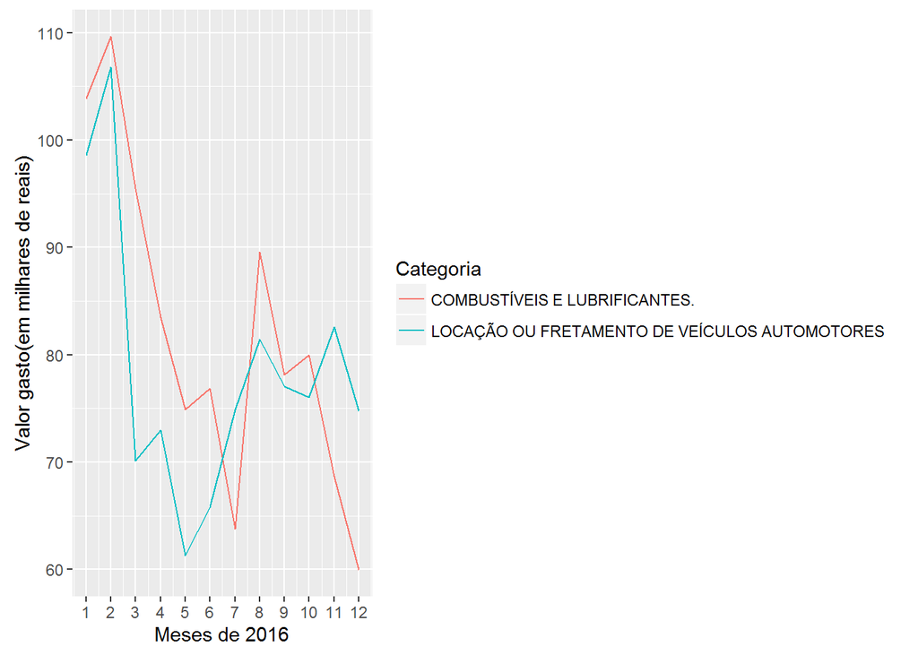

```r
categorias_terrestre = c("LOCAÇÃO OU FRETAMENTO DE VEÍCULOS AUTOMOTORES", "COMBUSTÍVEIS E LUBRIFICANTES.")
gastos_com_terrestre = gastos_pb %>%
  filter(txtDescricao %in% categorias_terrestre) %>%
  group_by(numMes, txtDescricao) %>%
  summarise(total_gasto = sum(vlrLiquido))

ggplot(gastos_com_terrestre, aes(x=numMes, y=total_gasto/1000, colour=txtDescricao))+
  geom_line( ) +
  scale_x_continuous(breaks = seq(1, 12, 1)) +
  labs(x="Meses de 2016", y="Valor gasto(em milhares de reais)", colour="Categoria")
```

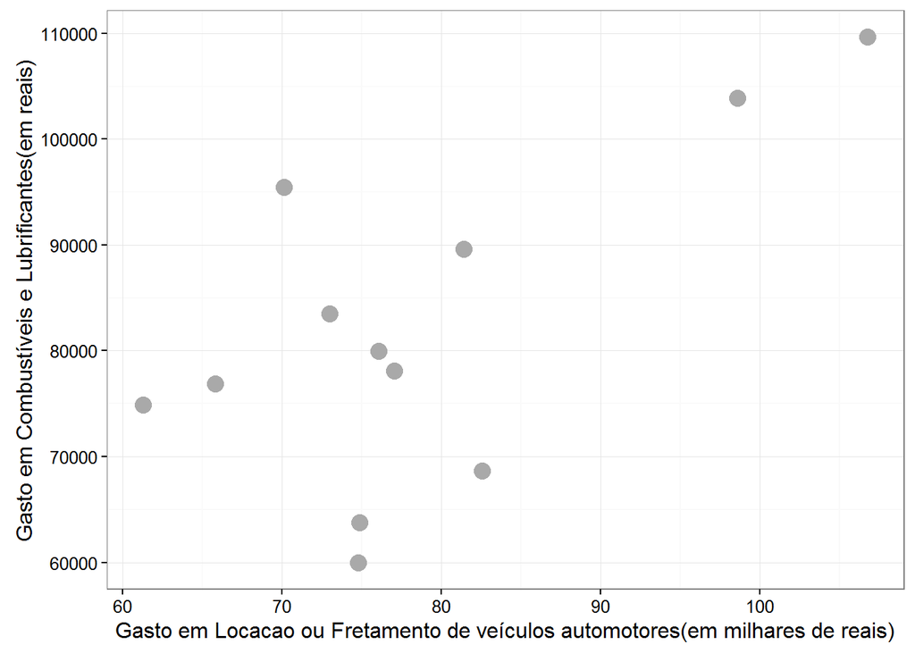

```r
terrestre_wide = spread(gastos_com_terrestre, txtDescricao, total_gasto)
terrestre_wide[is.na(terrestre_wide)] = 0
names(terrestre_wide)[names(terrestre_wide)=="LOCAÇÃO OU FRETAMENTO DE VEÍCULOS AUTOMOTORES"] <- "locacao_ou_fretamento_de_veiculos_automotores"
names(terrestre_wide)[names(terrestre_wide)=="COMBUSTÍVEIS E LUBRIFICANTES."] <- "combustiveis_lubrificantes"

ggplot(terrestre_wide, aes(x = locacao_ou_fretamento_de_veiculos_automotores/1000, y = combustiveis_lubrificantes)) +
  geom_point(colour = "darkgrey", size = 4) +
  theme_bw() +
  labs(x="Gasto em Locacao ou Fretamento de veículos automotores(em milhares de reais)", y="Gasto em Combustíveis e Lubrificantes(em reais)")
```

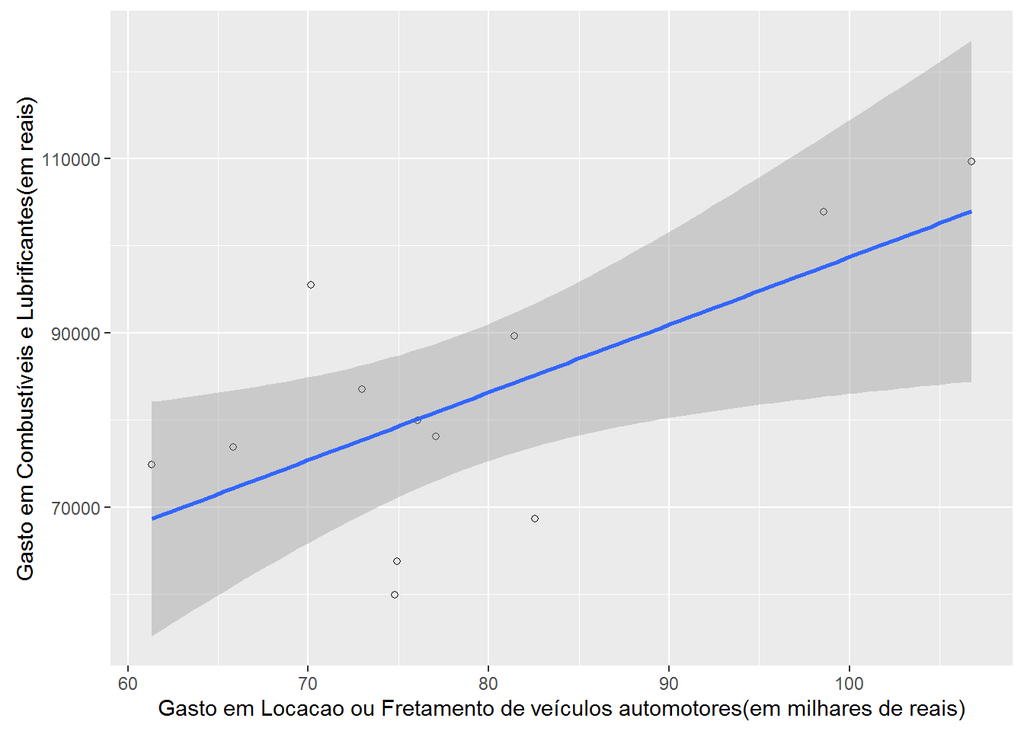

```r
ggplot(terrestre_wide, aes(x=locacao_ou_fretamento_de_veiculos_automotores/1000, y = combustiveis_lubrificantes)) +
  geom_point(shape=1) +    # Use hollow circles
  geom_smooth(method=lm) +
  labs(x="Gasto em Locacao ou Fretamento de veículos automotores(em milhares de reais)", y="Gasto em Combustíveis e Lubrificantes(em reais)")
```

```r
locacao_terrestre = gastos_com_terrestre %>%
  filter(txtDescricao == "LOCAÇÃO OU FRETAMENTO DE VEÍCULOS AUTOMOTORES") %>%
  select(mes = numMes, gasto_com_locacao = total_gasto)

combustiveis = gastos_com_terrestre %>%
  filter(txtDescricao == "COMBUSTÍVEIS E LUBRIFICANTES.") %>%
  select(mes = numMes, gasto_com_combustivel = total_gasto)

terrestre_merge = merge(locacao_terrestre, combustiveis, by = "mes")

correlacao = cor(terrestre_merge$gasto_com_locacao, terrestre_merge$gasto_com_combustivel)
show(correlacao)
```

```
## [1] 0.6528471
```

Então, com comportamento diferente do anterior, essa duas variáveis crescem juntas, obtendo uma correlação positiva. O que, parando para pensar, pode fazer sentido. Pois, se aumentar o número de carros alugados será necessário mais combustível para mantê-los.

### Seção de Combustível e Lubrificantes

Nessa parte vamos focar em gastos na categoria Combustível e Lubrificantes no estado da Paraíba. Aqui queremos responder as perguntas: 1. Quanto nossos parlamentares gastam nessa categoria? 2. Quais os fornecedores que mais arrecadam? 3. Quais são os fornecedores que mais se relacionam com parlamentares diferentes? 4. Os fornecedores mais relacionados são os que mais faturam?

Respondendo a primeira pergunta, vamos ver quanto se é gasto por mês nessa categoria.

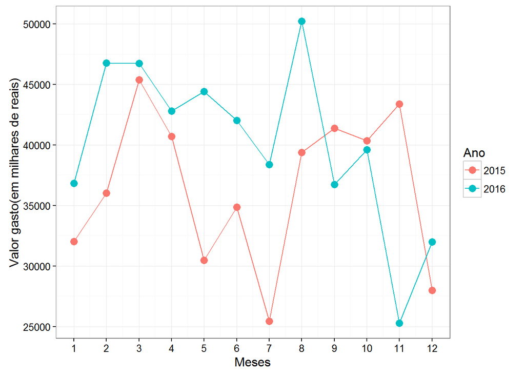

```r
ano_atual = 2017
combustivel_pb_mes = gastos_gerais %>%
  filter(txtDescricao == "COMBUSTÍVEIS E LUBRIFICANTES.", sgUF == "PB", numAno < ano_atual) %>%
  group_by(numAno, numMes) %>%
  summarise(total_gasto = sum(vlrLiquido))

ggplot(combustivel_pb_mes, aes(x=numMes, y=total_gasto, colour=factor(numAno))) +
  geom_point(size=3) +
  geom_line() +
  scale_x_continuous(breaks = seq(1, 12, 1)) +
  theme_bw() +
  labs(x="Meses", y="Valor gasto(em milhares de reais)", colour="Ano")
```

O gráfico não nos indica nenhum padrão nos gastos durante o ano, ou seja, não é algo crescente ou decrescente. Mas, podemos dizer que no ano de 2016 se gastou mais em *Combustíveis e Lubrificantes* durante a maior parte do ano quando comparado com 2015. Quem será que mais arrecadou? Abaixo temos o top 20 em arrecadações.

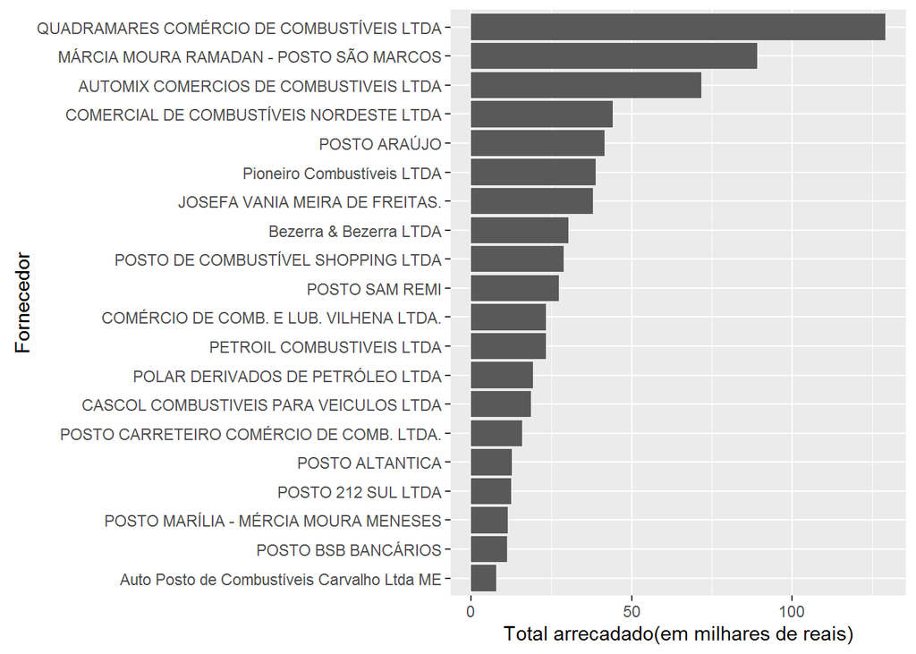

```r
arrecadacao_postos = gastos_gerais %>%
  filter(txtDescricao == "COMBUSTÍVEIS E LUBRIFICANTES.", sgUF == "PB", numAno < ano_atual) %>%
  group_by(txtFornecedor) %>%
  summarise(total_arrecadado = sum(vlrLiquido))

arrecadacao_postos = arrecadacao_postos[order(-arrecadacao_postos$total_arrecadado), ]
arrecadacao_postos_top20 = top_n(arrecadacao_postos, 20, total_arrecadado)

ggplot(arrecadacao_postos_top20, aes(x=reorder(txtFornecedor, total_arrecadado), y=total_arrecadado/1000)) +
  geom_bar(stat = "identity") +
  labs(x='Fornecedor', y='Total arrecadado(em milhares de reais)')+
  coord_flip()
```

O primeiro lugar vai para **QUADRAMARES COMÉRCIO DE COMBUSTÍVEIS LTDA** com mais de 128 mil reais arrecadados.

Vamos agora responder a pergunta 3 desta seção e ver a quantidade de relacionamentos de cada fornecedor.

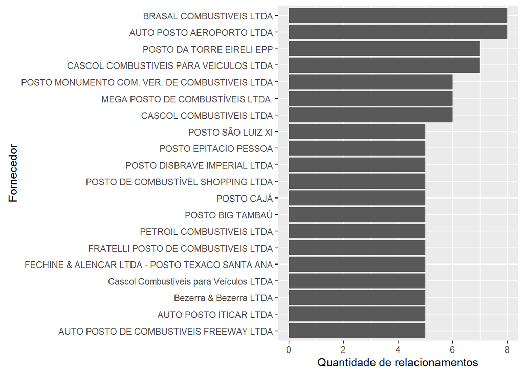

```r
total_arrecadado_por_relacionamento = gastos_gerais %>%
  filter(txtDescricao == "COMBUSTÍVEIS E LUBRIFICANTES.", sgUF == "PB", numAno < ano_atual) %>%
  group_by(txtCNPJCPF, txNomeParlamentar) %>%
  summarise(total_arrecadado = sum(vlrLiquido) )

cnpj_nome_fornecedor = gastos_gerais %>%
  filter(txtDescricao == "COMBUSTÍVEIS E LUBRIFICANTES.", sgUF == "PB", numAno < ano_atual) %>%
  select(txtCNPJCPF, txtFornecedor) %>%
  distinct(txtCNPJCPF, .keep_all = TRUE)


numero_de_relacionamentos = total_arrecadado_por_relacionamento %>%
  group_by(txtCNPJCPF)%>%
  summarise(relacionamentos = n())

relacionamento_merge = merge(numero_de_relacionamentos, cnpj_nome_fornecedor, by = "txtCNPJCPF")
relacionamento_merge = relacionamento_merge[order(-relacionamento_merge$relacionamentos), ]
relacionamento_merge_top = top_n(relacionamento_merge, 10, relacionamento_merge$relacionamentos) #n sei pq ta pegando mais que 10

ggplot(relacionamento_merge_top, aes(x=reorder(txtFornecedor, relacionamentos), y=relacionamentos)) +
  geom_bar(stat = "identity") +
  labs(x='Fornecedor', y='Quantidade de relacionamentos')+
  coord_flip()
```